# 00_income

zagor

2025-11-03

```r
rm(list = ls(all = TRUE))
gc()
```

```
##           used (Mb) gc trigger (Mb) max used (Mb)
## Ncells  617060 33.0    1419800 75.9   686457 36.7
## Vcells 1156843  8.9    8388608 64.0  1877160 14.4
```

# 1 packages

```r
library(magrittr)
library(data.table)
library(ggplot2)
```

# 2 palette

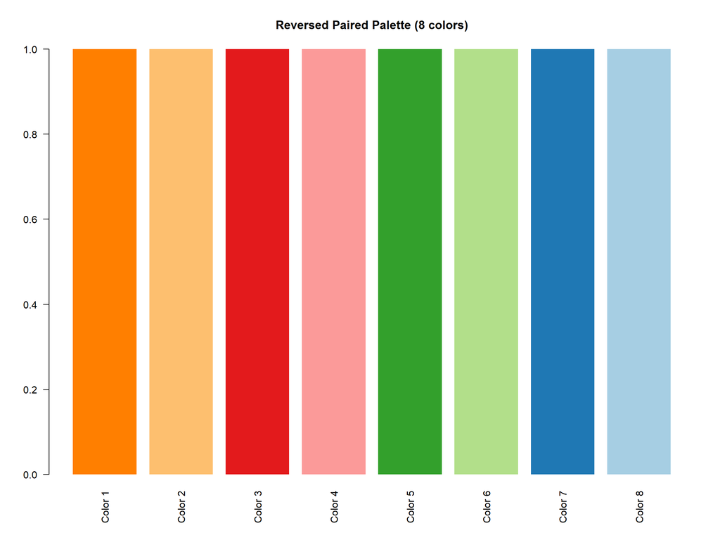

```r
pal = rev(RColorBrewer::brewer.pal(8, 'Paired'))
barplot(
  rep(1, length(pal)),
  col = pal,
  border = NA,
  names.arg = paste0("Color ", seq_along(pal)),
  main = "Reversed Paired Palette (8 colors)",
  las = 2
)
```

# 3 data

https://pxweb.stat.si/SiStatData/pxweb/en/Data/Data/0867347S.px/chart/chartViewColumn/

Notes:

- INCOME AFTER SOCIAL TRANSFERS
  - is (net) disposable household income.
  - It is calculated as the sum of net incomes (in cash) of all household members (employee cash or near cash income, including supplement for meals and transport to work, cash benefits or loses from self-employment, pensions, unemployment benefits, sickness benefits, education-related allowances, family allowances and social benefits, interests, dividends, regular inter-household cash transfers received) less regular inter-household cash transfers paid and regular taxes on wealth, including compensation for the use of building land.
  - To income in cash calculated in this way part of income in kind (benefit for the use of company car for private purposes and the value of withdrawals from a business by a self-employed person) is added.
- INCOME BEFORE SOCIAL TRANSFERS
  - is (net) disposable household income less social transfers (e.g. unemployment insurance, paid sick leave compensation, scholarship, child allowance, maternity leave compensation, adoptive parents’ compensation, allowance for nursing a child, assistance for goods for a new-born child, large family allowance, fathers’ compensation, parental allowance, financial social assistance, allowance for help and care, housing subsidies, disability benefits, old-age benefits, survivors’ benefits).
  - It is calculated using two definitions of income, depending on whether pensions are considered as social transfers or not: only » family benefits, disability pensions and other social transfers« or »social transfers including all pensions (old-age and survivors’ benefits)« are subtracted from total income.
  - In calculating the mean and the median, for income before social transfers the same number of persons is taken into account as for income after social transfers in an individual breakdown, so in some breakdowns for income before social transfers the value of the median inome can be very low or even negative.
- MEASURES
  - The OECD modified scale is used for the calculation of the EQUIVALISED INCOME (income per equivalent adult household member). The scale gives to the first adult in the household weight 1, to every other person aged 14 or more weight 0.5 and to children under 14 weight 0.3.
- YEAR
  - Income, poverty and social exclusion indicators are published for the SILC (Statistics on Income and Living Conditions) survey year. The data on income for calculating these indicators are from a year earlier, i.e. the year before the survey is conducted. With the 2022 EU-SILC survey, the methodology for calculating income before social transfers has changed slightly, so the data for income before social transfers from 2022 on are not completely comparable with the data for previous years.

```r
fp = file.path('..', 'input')
fn = "0867347S_20251103-205718.xlsx"
dt = openxlsx::read.xlsx(file.path(fp, fn), sheet = 'data', rows = 2:580)
dt = dt %>% tidyr::fill(X1:X5, .direction = "down")

colnames(dt)[1:5] = c('measureType', 'ageCohort', 'Education', 'Gender', 'incomeType')
setDT(dt)
dt
```

```
##                                       measureType ageCohort     Education
##                                            <char>    <char>        <char>
##   1: Mean equivalised income per household member   Age 16+ Basic or less
##   2: Mean equivalised income per household member   Age 16+ Basic or less
##   3: Mean equivalised income per household member   Age 16+ Basic or less
##   4: Mean equivalised income per household member   Age 16+ Basic or less
##   5: Mean equivalised income per household member   Age 16+ Basic or less
##  ---
## 572:           Median income per household member   Age 65+      Tertiary
## 573:           Median income per household member   Age 65+      Tertiary
## 574:           Median income per household member   Age 65+      Tertiary
## 575:           Median income per household member   Age 65+      Tertiary
## 576:           Median income per household member   Age 65+      Tertiary
##              Gender
##              <char>
```

[output cut: 50 more lines]

```r
dt.long = dt %>%
  tidyr::pivot_longer(
    cols = matches("^\\d{4}$"),
    names_to = "Year",
    values_to = "Income"
  ) %>%
  dplyr::mutate(Year = as.integer(Year))

table(dt.long$measureType, dt.long$ageCohort)
```

```
##
##                                                       Age 16+ Age 18-64 Age 18+
##   Mean equivalised income per household member            612       612     612
##   Mean income per household member                        612       612     612
##   Median income per equivalent adult household member     612       612     612
##   Median income per household member                      612       612     612
##
##                                                       Age 65+
##   Mean equivalised income per household member            612
##   Mean income per household member                        612
##   Median income per equivalent adult household member     612
##   Median income per household member                      612
```

```r
dt.long = dt.long[dt.long$ageCohort %in% "Age 18-64" & grep('^Mean income', dt.long$measureType), ]
table(dt.long$Gender, dt.long$Education)
```

```
##
##                  Basic or less Technical, general upper secondary Tertiary
##   Gender - TOTAL           204                                204      204
##   Men                      204                                204      204
##   Women                    204                                204      204
##
##                  Vocational secondary
##   Gender - TOTAL                  204
##   Men                             204
##   Women                           204
```

```r
dt.long = dt.long[dt.long$Gender != "Gender - TOTAL" , ]
table(dt.long$incomeType, dt.long$Year)
```

```
##
##                                                                                  2008
##   Income after social transfers                                                    32
##   Income before social transfers (pensions are included in social transfers)       32
##   Income before social transfers (pensions are not included in social transfers)   32
##
##                                                                                  2009
##   Income after social transfers                                                    32
##   Income before social transfers (pensions are included in social transfers)       32
##   Income before social transfers (pensions are not included in social transfers)   32
##
##                                                                                  2010
##   Income after social transfers                                                    32
##   Income before social transfers (pensions are included in social transfers)       32
##   Income before social transfers (pensions are not included in social transfers)   32
##
##                                                                                  2011
##   Income after social transfers                                                    32
##   Income before social transfers (pensions are included in social transfers)       32
##   Income before social transfers (pensions are not included in social transfers)   32
##
##                                                                                  2012
##   Income after social transfers                                                    32
##   Income before social transfers (pensions are included in social transfers)       32
##   Income before social transfers (pensions are not included in social transfers)   32
##
##                                                                                  2013
##   Income after social transfers                                                    32
##   Income before social transfers (pensions are included in social transfers)       32
##   Income before social transfers (pensions are not included in social transfers)   32
##
##                                                                                  2014
##   Income after social transfers                                                    32
##   Income before social transfers (pensions are included in social transfers)       32
##   Income before social transfers (pensions are not included in social transfers)   32
##
##                                                                                  2015
##   Income after social transfers                                                    32
##   Income before social transfers (pensions are included in social transfers)       32
##   Income before social transfers (pensions are not included in social transfers)   32
```

[output cut: 30 more lines]

```
##
##                                                                                  2022
##   Income after social transfers                                                    32
##   Income before social transfers (pensions are included in social transfers)       32
##   Income before social transfers (pensions are not included in social transfers)   32
##
##                                                                                  2023
##   Income after social transfers                                                    32
##   Income before social transfers (pensions are included in social transfers)       32
##   Income before social transfers (pensions are not included in social transfers)   32
##
##                                                                                  2024
##   Income after social transfers                                                    32
##   Income before social transfers (pensions are included in social transfers)       32
##   Income before social transfers (pensions are not included in social transfers)   32
```

```r
dt.long = dt.long[grep('not', dt.long$incomeType, invert = TRUE) , ]
dt.long = dt.long[! dt.long$Year  %in% c(2022,2023,2024), ]
```

# 4 refine variables

```r
dt.long$incomeType = gsub(" \\(.*", "", dt.long$incomeType)


dt.long = dt.long %>%
  dplyr::mutate(across(-Income, as.factor))

dt.long = dt.long %>%
  dplyr::mutate(Education = factor(Education, levels = c(
    "Basic or less",
    "Vocational secondary",
    "Technical, general upper secondary",
    "Tertiary"
  )))

dt.long = dt.long %>%
  dplyr::mutate(incomeType = factor(incomeType, levels = c(
    "Income before social transfers",
    "Income after social transfers"
  )))
```

# 5 basic plot

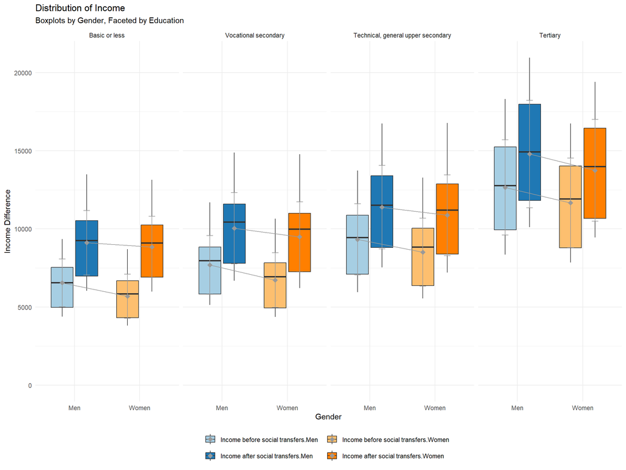

```r
ggplot(dt.long, aes(x = Gender, y = Income, fill = interaction(incomeType, Gender))) +
  geom_boxplot(outlier.shape = 21, outlier.fill = "white") +
  facet_wrap(~ Education, ncol = 8) +
  labs(
    title = "Distribution of Income",
    subtitle = "Boxplots by Gender, Faceted by Education",
    x = "Gender",
    y = "Income Difference"
  ) +
  theme_minimal() +
  geom_hline(yintercept = 0, alpha = 0) +
  scale_fill_manual(values = pal[c(8,7, 2,1)]) +
  theme(legend.position = "bottom") +
  guides(fill = guide_legend(nrow = 2, ncol = 2, title = NULL)) +
  stat_summary(
    aes(x = Gender, y = Income, group = incomeType),
    fun = mean,
    geom = "line",
    position = position_dodge(width = 0.75),
    color = "grey60",
    linewidth = 0.5
  ) +
  stat_summary(
    aes(x = Gender, y = Income, group = incomeType),
    fun = mean,
    geom = "point",
    position = position_dodge(width = 0.75),
    shape = 18,
    size = 3,
    color = "grey60"
  ) +
  stat_summary(
    aes(x = Gender, y = Income, group = incomeType),
    fun = mean,
    fun.min = function(x) mean(x) - sd(x),
    fun.max = function(x) mean(x) + sd(x),
    geom = "errorbar",
    position = position_dodge(width = 0.75),
    width = 0.2,
    color = "grey60"
  )
```

# 6 difference

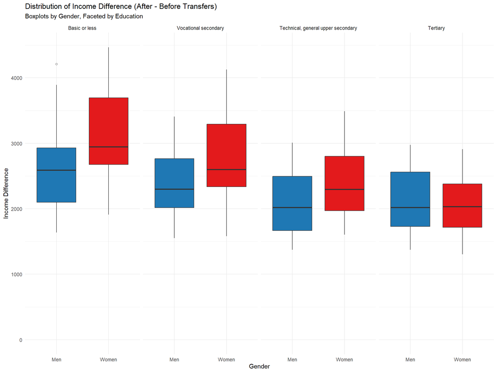

```r
dt.diff = dt.long %>%
  tidyr::pivot_wider(
    names_from = incomeType,
    values_from = Income
  ) %>%
  dplyr::rename(
    IncomeAfter = `Income after social transfers`,
    IncomeBefore = `Income before social transfers`
  ) %>%
  dplyr::mutate(Diff = IncomeAfter - IncomeBefore)


dt.summary = dt.diff %>%
  dplyr::group_by(Gender, Education) %>%
  dplyr::summarise(
    MeanDiff = mean(Diff, na.rm = TRUE),
    SE = sd(Diff, na.rm = TRUE) / sqrt(dplyr::n()),
    .groups = "drop"
  )

ggplot(dt.diff, aes(x = Gender, y = Diff, fill = Gender)) +
  geom_boxplot(outlier.shape = 21, outlier.fill = "white") +
  facet_wrap(~ Education, ncol = 4) +
  labs(
    title = "Distribution of Income Difference (After - Before Transfers)",
    subtitle = "Boxplots by Gender, Faceted by Education",
    x = "Gender",
    y = "Income Difference"
  ) +
  theme_minimal() +
  theme(legend.position = "none") +
  geom_hline(yintercept = 0, alpha = 0) +
  scale_fill_manual(values = pal[c(7,3)])
```

# 7 ratio

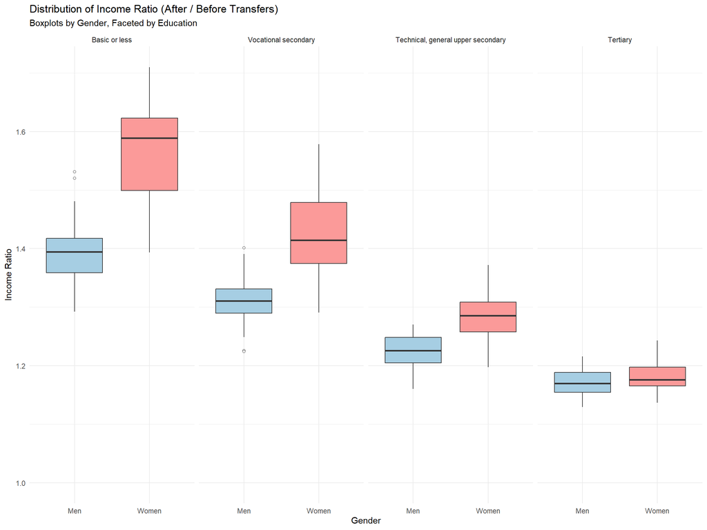

```r
dt.diff = dt.long %>%
  tidyr::pivot_wider(
    names_from = incomeType,
    values_from = Income
  ) %>%
  dplyr::rename(
    IncomeAfter = `Income after social transfers`,
    IncomeBefore = `Income before social transfers`
  ) %>%
  dplyr::mutate(Ratio = IncomeAfter / IncomeBefore)

dt.summary = dt.diff %>%
  dplyr::group_by(Gender, Education) %>%
  dplyr::summarise(
    MeanRatio = mean(Ratio, na.rm = TRUE),
    SE = sd(Ratio, na.rm = TRUE) / sqrt(dplyr::n()),
    .groups = "drop"
  )

ggplot(dt.diff, aes(x = Gender, y = Ratio, fill = Gender)) +
  geom_boxplot(outlier.shape = 21, outlier.fill = "white") +
  geom_hline(yintercept = 1, alpha = 0) +  # invisible reference line at ratio = 1
  facet_wrap(~ Education, ncol = 4) +
  labs(
    title = "Distribution of Income Ratio (After / Before Transfers)",
    subtitle = "Boxplots by Gender, Faceted by Education",
    x = "Gender",
    y = "Income Ratio"
  ) +
  theme_minimal() +
  theme(legend.position = "none") +
  geom_hline(yintercept = 1, alpha = 0) +
  scale_fill_manual(values = pal[c(8,4)])
```